# ggplot homework Week_5 Day_1

04/04/2022

```r
library(tidyverse)
```

```r
competitors <- CodeClanData::qb_competitors
device_data <- CodeClanData::qb_device_data
monthly_sales <- CodeClanData::qb_monthly_sales
revenue_breakdown <- CodeClanData::qb_revenue_breakdown
```

# 2 MVP

## 2.1 Part 1

**Question 1.** Take the data in the dataset qb_revenue_breakdown and make a stacked bar chart showing the sources of revenue across the two years in the dataset.

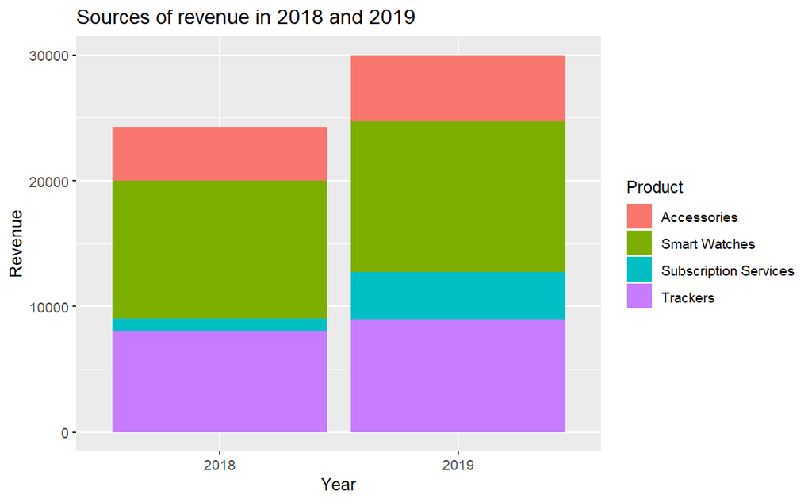

```r
ggplot(revenue_breakdown) +
  geom_bar(aes(x = Year, y = Revenue, fill = Product), stat = "identity") +
  labs(title = "Sources of revenue in 2018 and 2019")
```

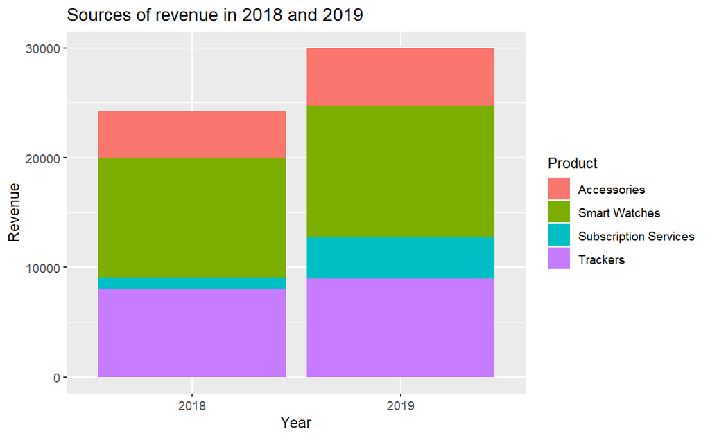

```r
#OR

ggplot(revenue_breakdown) +
  aes(x = Year, y = Revenue, fill = Product) +
  geom_col() +
  labs(title = "Sources of revenue in 2018 and 2019")
```

**Questino 2.** Make a line chart showing monthly sales of the “flagship product” - the ‘KwikBit Unit 1’ - over the last year. This data is inside qb_monthly_sales, but you will need to use filter() or subset() (base R).

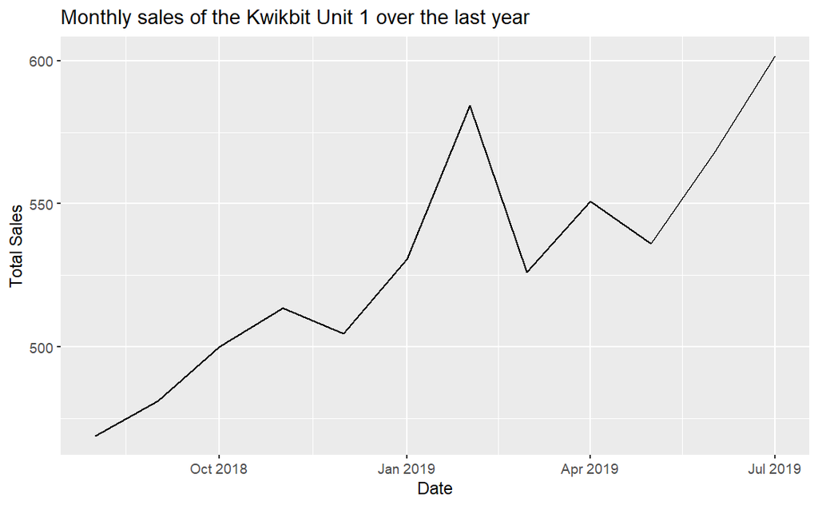

```r
kwikbit_unit1_sales <- monthly_sales %>%
  filter(Cashflow == "Kwikbit Unit 1 Sales")

ggplot(kwikbit_unit1_sales) +
  geom_line(aes(x = Date, y = Amount)) +
  labs(x = "Date",
       y = "Total Sales",
       title = "Monthly sales of the Kwikbit Unit 1 over the last year")
```

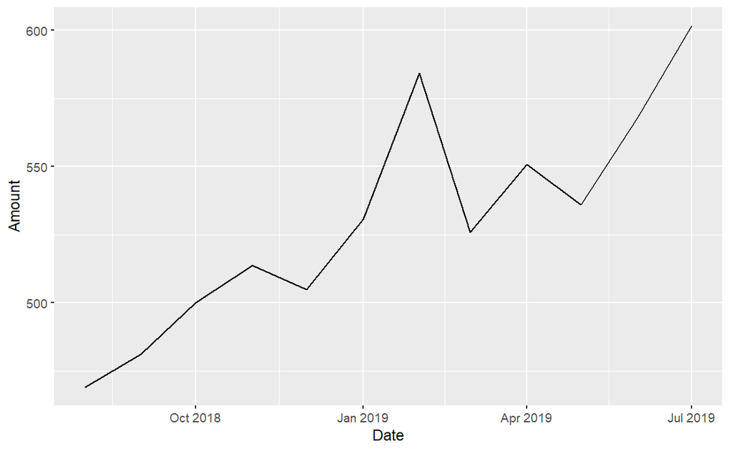

```r
#OR from the answers
kwikbit_sales <- subset(monthly_sales, Cashflow == "Kwikbit Unit 1 Sales")

ggplot(kwikbit_sales) +
 aes(x = Date, y = Amount) +
  geom_line()
```

**Question 3.** Make a line chart showing monthly revenue and costs over the last year. This data is also in qb_monthly_sales.

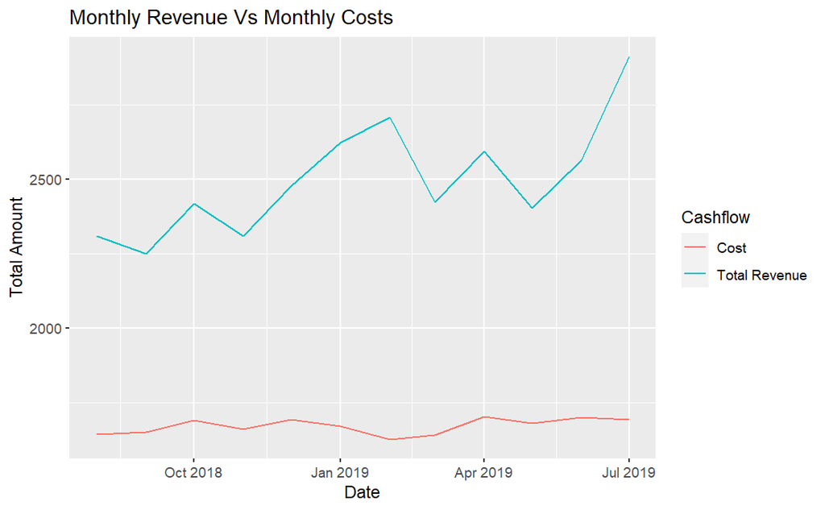

```r
monthly_revenue_and_costs <- monthly_sales %>%
  filter(Cashflow != "Kwikbit Unit 1 Sales")

ggplot(monthly_revenue_and_costs) +
  geom_line(aes(x = Date, y = Amount, group = Cashflow, colour = Cashflow)) +
  labs(x = "Date",
       y = "Total Amount",
       title = "Monthly Revenue Vs Monthly Costs")
```

**Question 4.** Show annual sales of personal fitness trackers over the last 5 years broken down by company as a ribbon plot (use geom_area). This data is in qb_competitors.

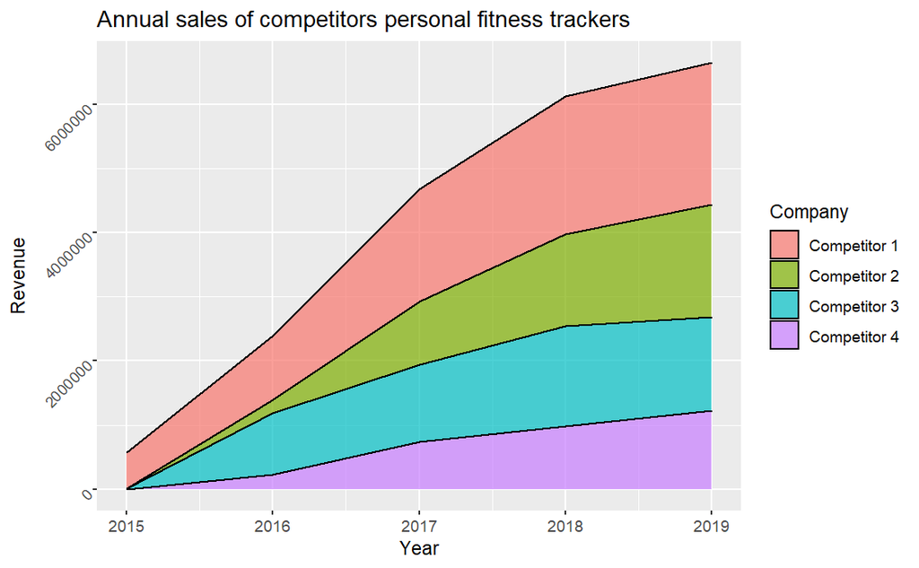

```r
options(scipen = 999)
ggplot(competitors) +
  geom_area(aes(x = Year, y = Revenue, fill = Company, colour = Company), alpha = 0.7, size = 0.5, colour = "black") +
  theme(axis.text.y = element_text(angle = 45, hjust = 1)) +
  labs(x = "Year",
       y = "Revenue",
       title = "Annual sales of competitors personal fitness trackers")
```

```r
# why does it change revenue values to e.g. "6e+06"? I think that means 6000000
# but is it a space issue? Doesn't make a difference if I angle it...
```

**Question 5.** Now show the sales from the four competitors as a line graph. Include an extra layer that shows the data points used to make the lines.

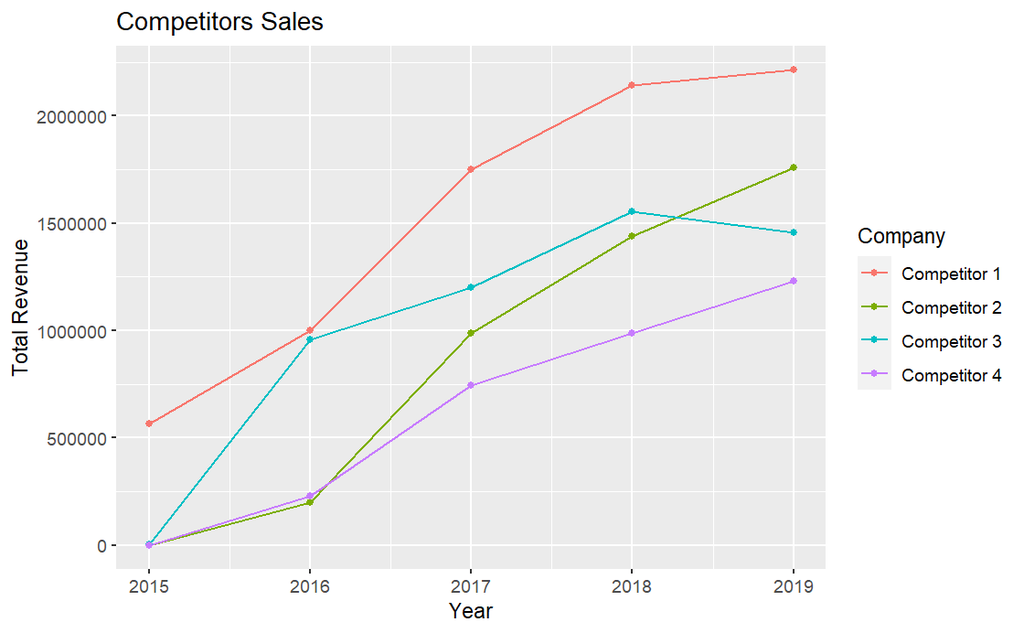

```r
ggplot(competitors) +
  geom_line(aes(x = Year, y = Revenue, group = Company, colour = Company)) +
  geom_point(aes(x = Year, y = Revenue, colour = Company)) +
  labs(x = "Year",
       y = "Total Revenue",
       title = "Competitors Sales")
```

**Question 6.** Now the company wants to compare the number of steps that their device counts vs. their competitors. Make a line graph of the number of steps throughout time, and use faceting to compare between companies and people. The data for this is in qb_device_data.